# Interesting Forecasting Applications with R

Doğanay Tuhan - IE360 - Spring 2020

# 1. Time series forecasting using ARIMA models

(https://blogs.oracle.com/datascience/introduction-to-forecasting-with-arima-in-r)

This example is important because it introduces the forecasting methodology using ARIMA models in R. The steps are loading R packages, examining the data, decomposing the data, assuring stationarity in the data by using autocorrelation plots, choosing model order, fitting an ARIMA model, evaluating and iterating.

# 2.Using Regression to Discover a Signal in Noise

(https://www.stat.pitt.edu/stoffer/tsa4/tsa4.pdf)

This example shows us how we can detect the signal in the noise using regression. The upper graph shows the data and the graph below shows the fitted line superimposed on the data. We use sine and cosine functions in regression because they represent the data best.

```r
set.seed(90210) # so you can reproduce these results
x = 2*cos(2*pi*1:500/50 + .6*pi) + rnorm(500,0,5)
z1 = cos(2*pi*1:500/50)
z2 = sin(2*pi*1:500/50)
summary(fit <- lm(x~0+z1+z2)) # zero to exclude the intercept
```

```
##
## Call:
## lm(formula = x ~ 0 + z1 + z2)
##
## Residuals:
##      Min       1Q   Median       3Q      Max
## -14.8584  -3.8525  -0.3186   3.3487  15.5440
##
## Coefficients:
##    Estimate Std. Error t value Pr(>|t|)
## z1  -0.7442     0.3274  -2.273   0.0235 *
## z2  -1.9949     0.3274  -6.093 2.23e-09 ***
## ---
## Signif. codes:  0 '***' 0.001 '**' 0.01 '*' 0.05 '.' 0.1 ' ' 1
##
## Residual standard error: 5.177 on 498 degrees of freedom
## Multiple R-squared:  0.07827,    Adjusted R-squared:  0.07456
## F-statistic: 21.14 on 2 and 498 DF,  p-value: 1.538e-09
```

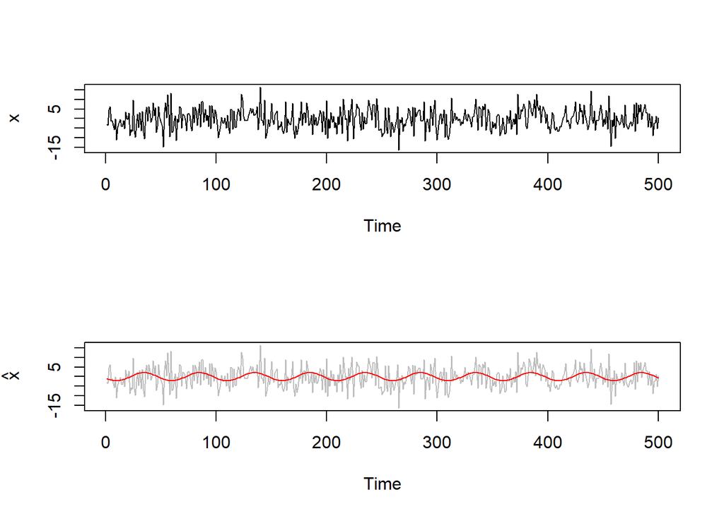

```r
par(mfrow=c(2,1))
plot.ts(x)
plot.ts(x, col=8, ylab=expression(hat(x)))
lines(fitted(fit), col=2)
```

# 3.Random Walk with Drift

(https://www.stat.pitt.edu/stoffer/tsa4/tsa4.pdf)

The random walk with drift model is given by xt = δ + xt−1 + wt for t = 1, 2, . . ., with initial condition x0 = 0, and where wt is white noise. The constant δ is called the drift, and when δ = 0, it is called simply a random walk. Here you see a random walk, σw = 1, with drift δ = .2 (upper jagged line), without drift, δ = 0 (lower jagged line), and straight (dashed) lines with slope δ.

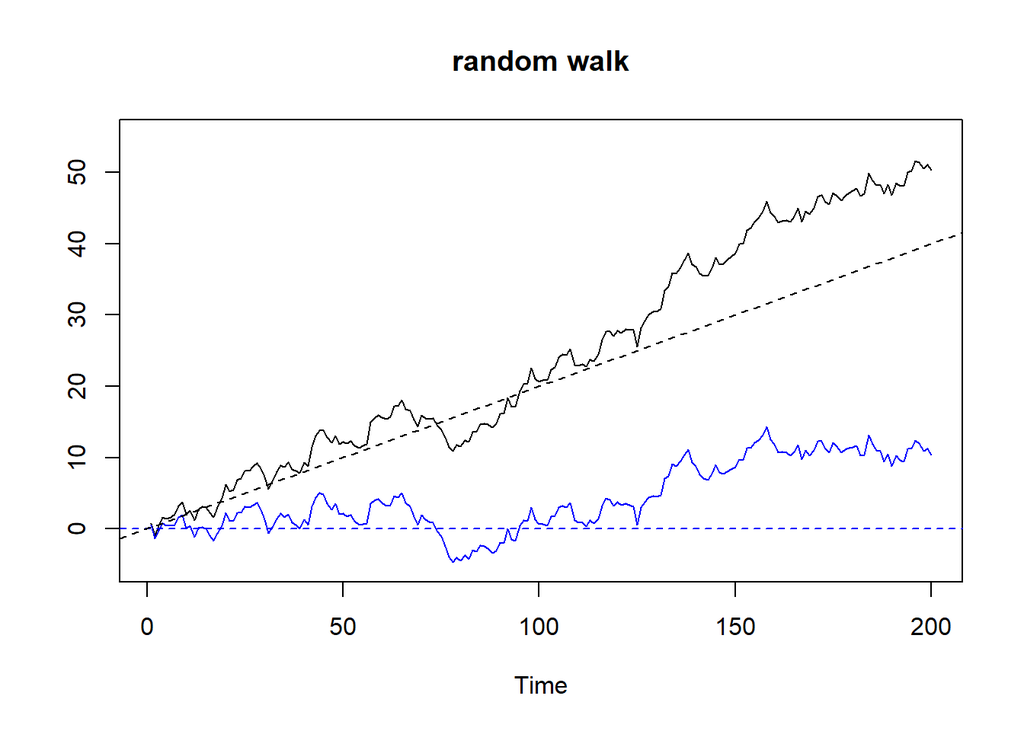

```r
set.seed(154) # so you can reproduce the results
w = rnorm(200); x = cumsum(w) # two commands in one line
wd = w +.2; xd = cumsum(wd)
plot.ts(xd, ylim=c(-5,55), main="random walk", ylab='')
lines(x, col=4); abline(h=0, col=4, lty=2); abline(a=0, b=.2, lty=2)
```

# 4.Moving Average Smoother

(http://db.ucsd.edu/static/TimeSeries.pdf)

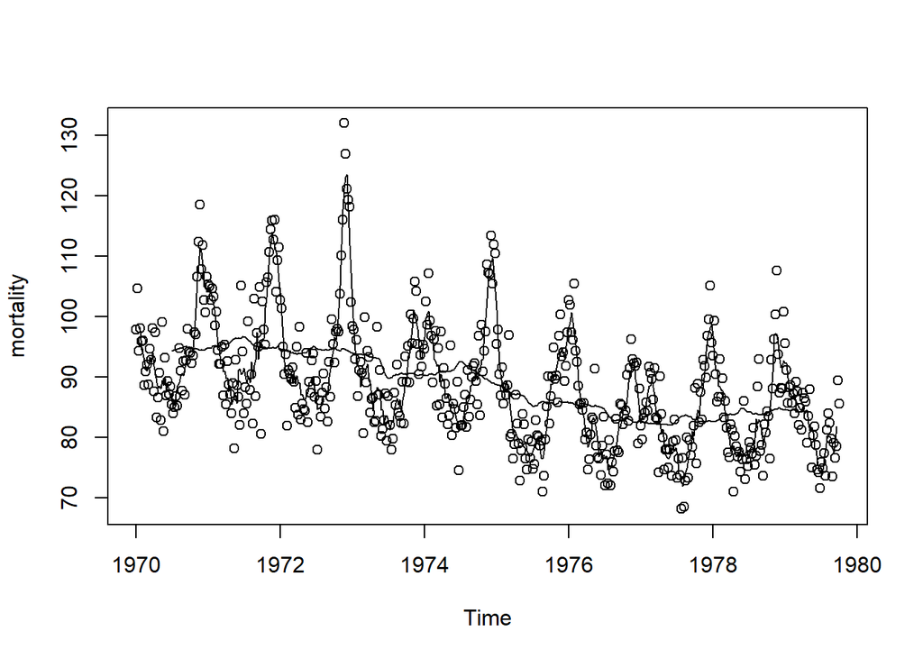

```r
ma5 = filter(cmort, sides=2, rep(1,5)/5)
ma53 = filter(cmort, sides=2, rep(1,53)/53)
plot(cmort, type="p", ylab="mortality")
lines(ma5); lines(ma53)
```

# 5.Missing Data Modification

(https://www.stat.pitt.edu/stoffer/tsa4/tsa4.pdf)

```r
y = cbind(WBC, PLT, HCT); num = nrow(y)
# make array of obs matrices
A = array(0, dim=c(3,3,num))
for(k in 1:num) { if (y[k,1] > 0) A[,,k]= diag(1,3) }
# Initial values
mu0 = matrix(0, 3, 1); Sigma0 = diag(c(.1, .1, 1), 3)
Phi = diag(1, 3); cQ = diag(c(.1, .1, 1), 3); cR = diag(c(.1, .1, 1), 3)
(em = EM1(num, y, A, mu0, Sigma0, Phi, cQ, cR, 100, .001))
```

```
## iteration    -loglikelihood
##     1          68.28328
##     2          -183.9361
##     3          -194.2051
##     4          -197.5444
##     5          -199.7442
##     6          -201.6431
##     7          -203.4226
##     8          -205.1253
##     9          -206.7595
##     10          -208.3251
##     11          -209.8209
##     12          -211.2464
##     13          -212.602
##     14          -213.8891
```

[output cut: 28 more lines]

```
## $Phi
##             [,1]        [,2]        [,3]
## [1,]  0.98052698 -0.03494377 0.008287009
## [2,]  0.05279121  0.93299479 0.005464917
## [3,] -1.46571679  2.25780951 0.795200344
##
## $Q
##              [,1]         [,2]       [,3]
## [1,]  0.013786772 -0.001724166 0.01882951
## [2,] -0.001724166  0.003032109 0.03528162
## [3,]  0.018829510  0.035281625 3.61897901
##
## $R
##             [,1]      [,2]      [,3]
## [1,] 0.007124671 0.0000000 0.0000000
## [2,] 0.000000000 0.0168669 0.0000000
## [3,] 0.000000000 0.0000000 0.9724247
##
## $mu0
##           [,1]
## [1,]  2.119269
## [2,]  4.407390
## [3,] 23.905038
##
## $Sigma0
##               [,1]          [,2]          [,3]
## [1,]  4.553949e-04 -5.249215e-05  0.0005877626
## [2,] -5.249215e-05  3.136928e-04 -0.0001199788
## [3,]  5.877626e-04 -1.199788e-04  0.1677365489
##
## $like
##  [1]   68.28328 -183.93608 -194.20509 -197.54440 -199.74425 -201.64313
##  [7] -203.42258 -205.12530 -206.75951 -208.32511 -209.82091 -211.24639
## [13] -212.60202 -213.88906 -215.10935 -216.26514 -217.35887 -218.39311
## [19] -219.37048 -220.29354 -221.16485 -221.98686 -222.76196 -223.49243
## [25] -224.18049 -224.82824 -225.43771 -226.01085 -226.54953 -227.05552
## [31] -227.53054 -227.97621 -228.39410 -228.78569 -229.15242 -229.49563
## [37] -229.81661 -230.11659 -230.39674 -230.65816 -230.90189 -231.12893
##
## $niter
## [1] 42
##
## $cvg
## [1] 0.0009832656
```

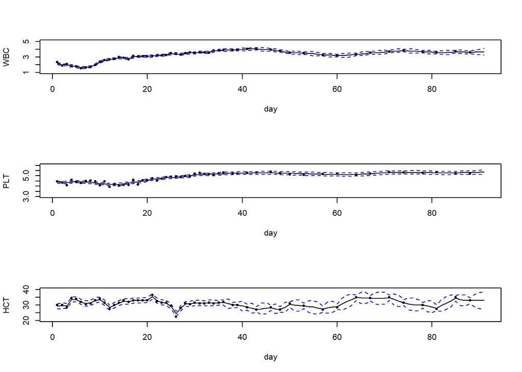

```r
# Graph smoother
ks = Ksmooth1(num, y, A, em$mu0, em$Sigma0, em$Phi, 0, 0, chol(em$Q),
chol(em$R), 0)
y1s = ks$xs[1,,]; y2s = ks$xs[2,,]; y3s = ks$xs[3,,]
p1 = 2*sqrt(ks$Ps[1,1,]); p2 = 2*sqrt(ks$Ps[2,2,]); p3 = 2*sqrt(ks$Ps[3,3,])
par(mfrow=c(3,1))
plot(WBC, type='p', pch=19, ylim=c(1,5), xlab='day')
lines(y1s); lines(y1s+p1, lty=2, col=4); lines(y1s-p1, lty=2, col=4)
plot(PLT, type='p', ylim=c(3,6), pch=19, xlab='day')
lines(y2s); lines(y2s+p2, lty=2, col=4); lines(y2s-p2, lty=2, col=4)
plot(HCT, type='p', pch=19, ylim=c(20,40), xlab='day')
lines(y3s); lines(y3s+p3, lty=2, col=4); lines(y3s-p3, lty=2, col=4)
```